# 08 Lasso, Ridge, and Elastic-Net Regression in Supervised Learning

Linear regression is a fundamental tool in statistics and machine learning. However, when dealing with high-dimensional data, or when multicollinearity (correlation between predictors) is present, plain linear regression can have limitations. To address these challenges, researchers have introduced penalized regression techniques such as Lasso, Ridge, and Elastic-Net regression. These methods not only help in regularization but also in feature selection.

Regular linear regression minimizes the sum of squares to find the line of best fit, here we out a penalty on the accuracy of the model for the size of the coefficients, large coefficients means larger error and is less accurate compared to regular linear regression to minimize overfitting.

LASSO minimizes l1 norm (absolute value norm) pushing out predictors, assigning coefficient of 0s essentially saying its not there.

Ridge minimizes the l2 norm (degree 2 norm) always keep every single predictor variable even if its super small

Elastic net combines both.

In this lecture note, we will dive deep into these methods, understand their mathematical underpinnings, and apply them using the R language.

# Prepare the workspace

```r
options(
  digits = 2,
  scipen = 999,
  warn = -1
)
rm(
  list = ls()
)
library(magrittr)
```

# Load our data

```r
set.seed(
  seed = 823
)
M <- readr::read_csv(
  file = "/Users/thienpham/Data Mining/data/prepared_house_prices.csv",
  col_types = "cnnnnnnnnnnnnnnnnnnnnnnnnnnnnnnnnnnnnnnnnnnnnnnnnnnnnnnnnnnnnnnnnnnnnnnnnnnnnnnnccn",
  name_repair = janitor::make_clean_names
) %>%
  dplyr::filter(train_test == "Train") %>%
  as.data.frame()
M$train_test <- sample(
  x = c("Train","Validation"),
  size = nrow(
    x = M
  ),
  replace = TRUE
)
v_predictors <- c(
  "ms_sub_class","ms_zoning","lot_frontage","lot_area","street","alley","lot_shape","land_contour","utilities","lot_config","land_slope","neighborhood","condition1","condition2","bldg_type","house_style","overall_qual","overall_cond","year_built","year_remod_add","roof_style","roof_matl","exterior1st","exterior2nd","mas_vnr_type","mas_vnr_area","exter_qual","exter_cond","foundation","bsmt_qual","bsmt_cond","bsmt_exposure","bsmt_fin_type1","bsmt_fin_sf1","bsmt_fin_type2","bsmt_fin_sf2","bsmt_unf_sf","total_bsmt_sf","heating","heating_qc","central_air","electrical","x1st_flr_sf","x2nd_flr_sf","low_qual_fin_sf","gr_liv_area","bsmt_full_bath","bsmt_half_bath","full_bath","half_bath","bedroom_abv_gr","kitchen_abv_gr","kitchen_qual","tot_rms_abv_grd","functional","fireplaces","fireplace_qu","garage_type","garage_yr_blt","garage_finish","garage_cars","garage_area","garage_qual","garage_cond","paved_drive","wood_deck_sf","open_porch_sf","enclosed_porch","x3ssn_porch","screen_porch","pool_qc","fence","misc_feature","misc_val","mo_sold","yr_sold","sale_type","sale_condition"
)
```

## Feature Scaling

Regularized regression techniques are sensitive to the scale of the input features. Before applying these techniques, it’s essential to standardize or normalize the features.

In R, this can be achieved using the `scale` function:

Be sure to save the column means and standard deviations for future scoring data

```r
colMeans(
  x = M[,v_predictors]
)
```

```
##    ms_sub_class       ms_zoning    lot_frontage        lot_area          street
##           0.642           0.788          70.003          94.604           0.996
##           alley       lot_shape    land_contour       utilities      lot_config
##           0.938           0.366           0.898           0.999           0.721
##      land_slope    neighborhood      condition1      condition2       bldg_type
##           0.947           0.503           0.863           0.990           0.836
##     house_style    overall_qual    overall_cond      year_built  year_remod_add
##           0.355           0.632           0.577     1943668.850     1970050.242
##      roof_style       roof_matl     exterior1st     exterior2nd    mas_vnr_type
##           0.782           0.982           0.505           0.508           0.398
##    mas_vnr_area      exter_qual      exter_cond      foundation       bsmt_qual
##           1.169           0.370           0.878           0.449           0.506
##       bsmt_cond   bsmt_exposure  bsmt_fin_type1    bsmt_fin_sf1  bsmt_fin_type2
##           0.898           0.653           0.581           9.575           0.860
##    bsmt_fin_sf2     bsmt_unf_sf   total_bsmt_sf         heating      heating_qc
##           0.078          35.922         379.554           0.978           0.508
##     central_air      electrical     x1st_flr_sf     x2nd_flr_sf low_qual_fin_sf
##           0.935           0.914           7.007           1.893           2.489
##     gr_liv_area  bsmt_full_bath  bsmt_half_bath       full_bath       half_bath
##           7.267           0.425           0.056           1.571           0.375
##  bedroom_abv_gr  kitchen_abv_gr    kitchen_qual tot_rms_abv_grd      functional
##           2.864           1.046           0.470           1.847           0.932
##      fireplaces    fireplace_qu     garage_type   garage_yr_blt   garage_finish
##           0.610           0.514           0.656     1953985.894           0.530
##     garage_cars     garage_area     garage_qual     garage_cond     paved_drive
##           1.764         471.629           0.898           0.908           0.918
##    wood_deck_sf   open_porch_sf  enclosed_porch     x3ssn_porch    screen_porch
##           2.009           2.432           0.109           2.239          14.232
##         pool_qc           fence    misc_feature        misc_val         mo_sold
##           0.995           0.808           0.963          22.062           6.322
##         yr_sold       sale_type  sale_condition
##        2007.816           0.868           0.821
```

```r
sapply(
  X = M[,v_predictors],
  FUN = sd
)
```

```
##    ms_sub_class       ms_zoning    lot_frontage        lot_area          street
##           0.479           0.409          20.555          17.981           0.064
##           alley       lot_shape    land_contour       utilities      lot_config
##           0.242           0.482           0.303           0.026           0.449
##      land_slope    neighborhood      condition1      condition2       bldg_type
##           0.225           0.500           0.344           0.101           0.371
##     house_style    overall_qual    overall_cond      year_built  year_remod_add
##           0.479           0.483           0.494       58450.245       40861.548
##      roof_style       roof_matl     exterior1st     exterior2nd    mas_vnr_type
##           0.413           0.132           0.500           0.500           0.490
##    mas_vnr_area      exter_qual      exter_cond      foundation       bsmt_qual
##           1.414           0.483           0.327           0.498           0.500
##       bsmt_cond   bsmt_exposure  bsmt_fin_type1    bsmt_fin_sf1  bsmt_fin_type2
##           0.303           0.476           0.494           7.068           0.347
##    bsmt_fin_sf2     bsmt_unf_sf   total_bsmt_sf         heating      heating_qc
##           0.217          17.355         126.257           0.146           0.500
##     central_air      electrical     x1st_flr_sf     x2nd_flr_sf low_qual_fin_sf
##           0.247           0.281           0.310           2.172          18.905
##     gr_liv_area  bsmt_full_bath  bsmt_half_bath       full_bath       half_bath
##           0.322           0.516           0.230           0.539           0.484
##  bedroom_abv_gr  kitchen_abv_gr    kitchen_qual tot_rms_abv_grd      functional
##           0.778           0.209           0.499           0.238           0.253
##      fireplaces    fireplace_qu     garage_type   garage_yr_blt   garage_finish
##           0.635           0.500           0.475       49882.456           0.499
##     garage_cars     garage_area     garage_qual     garage_cond     paved_drive
##           0.739         209.429           0.303           0.289           0.275
##    wood_deck_sf   open_porch_sf  enclosed_porch     x3ssn_porch    screen_porch
##           2.115           2.273           0.267          17.633          50.907
##         pool_qc           fence    misc_feature        misc_val         mo_sold
##           0.069           0.394           0.189         123.380           2.704
##         yr_sold       sale_type  sale_condition
##           1.328           0.339           0.384
```

```r
M[,v_predictors] <- scale(
  x = M[,v_predictors]
)
```

# Variable Importance

Variable importance provides insights into which features are most influential in predicting the response variable. For Lasso and Ridge regression, the magnitude of regression coefficients can be a proxy for feature importance.

In the context of regularized regression, variables with larger absolute coefficients are more important. Remember, though, Lasso regression can shrink coefficients to zero, indicating that the corresponding feature is not important.

# Regularization Techniques and Hyperparameters

Regularization techniques, such as Lasso, Ridge, and Elastic-Net, introduce a penalty to the loss function. This penalty controls the complexity of the model, reducing the chance of overfitting.

Key hyperparameters in these techniques include:

- $\lambda$: Regularization strength. A higher value of $\lambda$ will impose a stronger penalty, potentially shrinking coefficients closer to zero.
- $\alpha$: Mix ratio in Elastic-Net regression. Dictates the balance between Lasso and Ridge penalties.
- alpha of 0(ridge) or 1(LASSO) youll get ridge or lasso and something in between is a combination

Selecting the right hyperparameters is crucial. Techniques like cross-validation can be helpful in finding optimal values.

# Ridge Regression

Ridge regression introduces a penalty term for the magnitude of coefficients. This penalty term ensures that the model remains robust even when there is multicollinearity.

## Mathematical Formulation

The cost function for ridge regression can be written as:
$$J(\theta) = \sum_{i=1}^{n} (y_i - x_i^T \theta)^2 + \lambda
\sum_{j=1}^{p} \theta_j^2$$
Where: - $y_i$ is the actual value. - $x_i$ is the feature vector. - $\theta$ is the coefficient vector. - $\lambda$ is the regularization parameter.

Squares the coefficients, add them up, multiplying by lambda and add it to the error term of our model. Ridge will never kick out any of our variables. ## R Implementation

```r
glmnet_ridge <- glmnet::glmnet(
  x = M[,v_predictors] %>%                                  # x: predictors
    dplyr::filter(M$train_test == "Train") %>%
    as.matrix(),
  y = M$box_cox_sale_price[M$train_test == "Train"],        # y: target variable
  alpha = 0,
  lambda = 0.5
)
glmnet_ridge
```

```
##
## Call:  glmnet::glmnet(x = M[, v_predictors] %>% dplyr::filter(M$train_test ==      "Train") %>% as.matrix(), y = M$box_cox_sale_price[M$train_test ==      "Train"], alpha = 0, lambda = 0.5)
##
##   Df %Dev Lambda
## 1 78 85.6    0.5
```

```r
# to get coefficients
coef(
  object = glmnet_ridge
) %>%
  as.matrix() %>%
  as.data.frame() %>%
  dplyr::arrange(s0) # sorted by coefficient size, top and bottom are where all the important variables will be
```

```
##                       s0
## bsmt_exposure   -0.01185
## roof_style      -0.01146
## sale_type       -0.00869
## kitchen_abv_gr  -0.00620
## roof_matl       -0.00406
## lot_config      -0.00324
## heating         -0.00217
## alley           -0.00197
## land_slope      -0.00159
## enclosed_porch  -0.00101
## overall_cond    -0.00095
## low_qual_fin_sf -0.00086
## bsmt_unf_sf     -0.00078
## yr_sold         -0.00063
## x3ssn_porch     -0.00055
## pool_qc         -0.00035
## sale_condition  -0.00011
## land_contour     0.00031
## bsmt_fin_type2   0.00040
## exterior2nd      0.00048
## exter_cond       0.00065
## misc_feature     0.00097
## street           0.00130
## misc_val         0.00158
## bsmt_half_bath   0.00270
## utilities        0.00315
## bsmt_fin_sf2     0.00331
## garage_qual      0.00346
## condition2       0.00424
## mas_vnr_type     0.00467
## mas_vnr_area     0.00469
## fence            0.00497
## bsmt_cond        0.00498
## exterior1st      0.00517
## bldg_type        0.00533
## mo_sold          0.00557
## house_style      0.00587
## lot_shape        0.00634
## ms_zoning        0.00638
```

[output cut: 25 more lines]

```
## fireplaces       0.01801
## kitchen_qual     0.01843
## lot_area         0.01849
## year_remod_add   0.01856
## bsmt_fin_sf1     0.01867
## exter_qual       0.01945
## full_bath        0.01999
## neighborhood     0.02071
## garage_cars      0.02222
## garage_area      0.02296
## tot_rms_abv_grd  0.02313
## x1st_flr_sf      0.02963
## total_bsmt_sf    0.03057
## gr_liv_area      0.03599
## (Intercept)     12.02192
```

# Lasso Regression

Lasso regression, like ridge regression, also adds a penalty term. However, the difference is in the type of penalty. Lasso can shrink some coefficients exactly to zero, making it useful for feature selection.

## Mathematical Formulation

The cost function for lasso regression is:
$$J(\theta) = \sum_{i=1}^{n} (y_i - x_i^T \theta)^2 + \lambda
\sum_{j=1}^{p} |\theta_j|$$

instead of squaring the coefficients, takes abs value then add it up, multiple by lamba and add it to the error term. This will set a coefficent to 0 doing variable selection for us. ## R Implementation

```r
glmnet_lasso <- glmnet::glmnet(
  x = M[,v_predictors] %>%
    dplyr::filter(M$train_test == "Train") %>%
    as.matrix(),
  y = M$box_cox_sale_price[M$train_test == "Train"],
  alpha = 1,
  lambda = 0.025
)
glmnet_lasso
```

```
##
## Call:  glmnet::glmnet(x = M[, v_predictors] %>% dplyr::filter(M$train_test ==      "Train") %>% as.matrix(), y = M$box_cox_sale_price[M$train_test ==      "Train"], alpha = 1, lambda = 0.025)
##
##   Df %Dev Lambda
## 1 25 85.6  0.025
```

```r
coef(
  object = glmnet_lasso
) %>%
  as.matrix() %>%
  as.data.frame() %>%
  dplyr::arrange(s0)
```

```
##                       s0
## bsmt_exposure   -0.00334
## kitchen_abv_gr  -0.00128
## ms_zoning        0.00000
## lot_frontage     0.00000
## street           0.00000
## alley            0.00000
## lot_shape        0.00000
## land_contour     0.00000
## utilities        0.00000
## lot_config       0.00000
## land_slope       0.00000
## condition2       0.00000
## bldg_type        0.00000
## house_style      0.00000
## overall_cond     0.00000
## roof_style       0.00000
## roof_matl        0.00000
## exterior1st      0.00000
## exterior2nd      0.00000
## mas_vnr_type     0.00000
## mas_vnr_area     0.00000
## exter_cond       0.00000
## bsmt_cond        0.00000
## bsmt_fin_type1   0.00000
## bsmt_fin_type2   0.00000
## bsmt_fin_sf2     0.00000
## bsmt_unf_sf      0.00000
## heating          0.00000
## electrical       0.00000
## x2nd_flr_sf      0.00000
## low_qual_fin_sf  0.00000
## bsmt_full_bath   0.00000
## bsmt_half_bath   0.00000
## full_bath        0.00000
## half_bath        0.00000
## bedroom_abv_gr   0.00000
## tot_rms_abv_grd  0.00000
## fireplace_qu     0.00000
## garage_yr_blt    0.00000
```

[output cut: 25 more lines]

```
## overall_qual     0.01110
## kitchen_qual     0.01402
## lot_area         0.02009
## fireplaces       0.02082
## year_built       0.02250
## central_air      0.02329
## garage_area      0.02346
## exter_qual       0.02423
## bsmt_fin_sf1     0.02570
## year_remod_add   0.03459
## garage_cars      0.03745
## neighborhood     0.04365
## total_bsmt_sf    0.06172
## gr_liv_area      0.13179
## (Intercept)     12.02174
```

# Elastic-Net Regression

Elastic-Net regression combines the penalties of ridge and lasso regression. It can be especially useful when there are multiple correlated features.

## Mathematical Formulation

Uses alpha to do a weighted average of the 2 aspects from ridge and lasso (the squaring of the coefficients and the absolute value).

```r
glmnet_elasticnet <- glmnet::glmnet(
  x = M[,v_predictors] %>%
    dplyr::filter(M$train_test == "Train") %>%
    as.matrix(),
  y = M$box_cox_sale_price[M$train_test == "Train"],
  alpha = 0.5,
  lambda = 0.025
)
glmnet_elasticnet
```

```
##
## Call:  glmnet::glmnet(x = M[, v_predictors] %>% dplyr::filter(M$train_test ==      "Train") %>% as.matrix(), y = M$box_cox_sale_price[M$train_test ==      "Train"], alpha = 0.5, lambda = 0.025)
##
##   Df %Dev Lambda
## 1 34 87.4  0.025
```

```r
coef(
  object = glmnet_elasticnet
) %>%
  as.matrix() %>%
  as.data.frame() %>%
  dplyr::arrange(s0)
```

```
##                         s0
## bsmt_exposure   -0.0110933
## kitchen_abv_gr  -0.0092076
## roof_style      -0.0062271
## lot_frontage     0.0000000
## street           0.0000000
## alley            0.0000000
## lot_shape        0.0000000
## land_contour     0.0000000
## utilities        0.0000000
## lot_config       0.0000000
## land_slope       0.0000000
## condition2       0.0000000
## bldg_type        0.0000000
## house_style      0.0000000
## overall_cond     0.0000000
## roof_matl        0.0000000
## exterior1st      0.0000000
## exterior2nd      0.0000000
## mas_vnr_type     0.0000000
## mas_vnr_area     0.0000000
## exter_cond       0.0000000
## bsmt_cond        0.0000000
## bsmt_fin_type1   0.0000000
## bsmt_fin_type2   0.0000000
## bsmt_fin_sf2     0.0000000
## bsmt_unf_sf      0.0000000
## heating          0.0000000
## x2nd_flr_sf      0.0000000
## low_qual_fin_sf  0.0000000
## bsmt_half_bath   0.0000000
## bedroom_abv_gr   0.0000000
## fireplace_qu     0.0000000
## garage_yr_blt    0.0000000
## garage_finish    0.0000000
## garage_qual      0.0000000
## open_porch_sf    0.0000000
## enclosed_porch   0.0000000
## x3ssn_porch      0.0000000
## screen_porch     0.0000000
```

[output cut: 25 more lines]

```
## condition1       0.0181622
## functional       0.0197182
## fireplaces       0.0223233
## lot_area         0.0248998
## exter_qual       0.0250931
## x1st_flr_sf      0.0258381
## garage_area      0.0260363
## central_air      0.0282201
## bsmt_fin_sf1     0.0317423
## garage_cars      0.0322901
## year_remod_add   0.0357083
## neighborhood     0.0389328
## total_bsmt_sf    0.0531905
## gr_liv_area      0.1150288
## (Intercept)     12.0218461
```

# Regularization Techniques, Hyperparameters, and Cross-validation

Regularization in regression models, particularly in Lasso, Ridge, and Elastic-Net, introduces the complexity of determining the optimal hyperparameters, mainly the penalty parameter $\lambda$. The challenge lies in determining a $\lambda$ that generalizes well to unseen data.

## Cross-validation with `cv.glmnet`

The `cv.glmnet` function from the `glmnet` package in R performs k-fold cross-validation to determine the best $\lambda$. This function automatically tries out many different $\lambda$ values and uses cross-validation to determine which one results in the lowest prediction error.

```r
cv.glmnet_ridge <- glmnet::cv.glmnet(
  x = M[,v_predictors] %>%
    dplyr::filter(M$train_test == "Train") %>%
    as.matrix(),
  y = M$box_cox_sale_price[M$train_test == "Train"],
  alpha = 0
)
cv.glmnet_ridge
```

```
##
## Call:  glmnet::cv.glmnet(x = M[, v_predictors] %>% dplyr::filter(M$train_test ==      "Train") %>% as.matrix(), y = M$box_cox_sale_price[M$train_test ==      "Train"], alpha = 0)
##
## Measure: Mean-Squared Error
##
##     Lambda Index Measure      SE Nonzero
## min  0.122    85  0.0269 0.00237      78
## 1se  0.494    70  0.0290 0.00224      78
```

This function identifies 2 lambdas for us, the minimum penalty and the largets lambda within 1 standard error of the minimum. so we went with lambda = 0.494 or 0.5 for steakholders

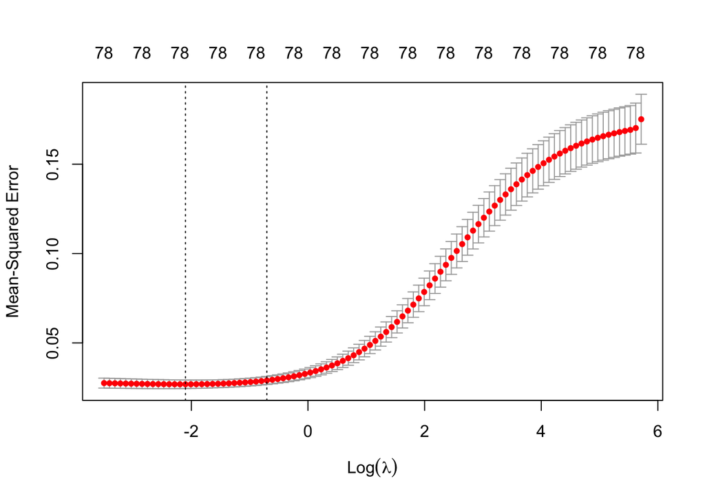

```r
plot(
  x = cv.glmnet_ridge
)
```

Shows the minimum then shows 1 standard deviation to the right.

```r
cv.glmnet_lasso <- glmnet::cv.glmnet(
  x = M[,v_predictors] %>%
    dplyr::filter(M$train_test == "Train") %>%
    as.matrix(),
  y = M$box_cox_sale_price[M$train_test == "Train"],
  alpha = 1
)
cv.glmnet_lasso
```

```
##
## Call:  glmnet::cv.glmnet(x = M[, v_predictors] %>% dplyr::filter(M$train_test ==      "Train") %>% as.matrix(), y = M$box_cox_sale_price[M$train_test ==      "Train"], alpha = 1)
##
## Measure: Mean-Squared Error
##
##      Lambda Index Measure      SE Nonzero
## min 0.00805    40  0.0244 0.00267      38
## 1se 0.02240    29  0.0268 0.00297      25
```

Here lambda = 0.02240

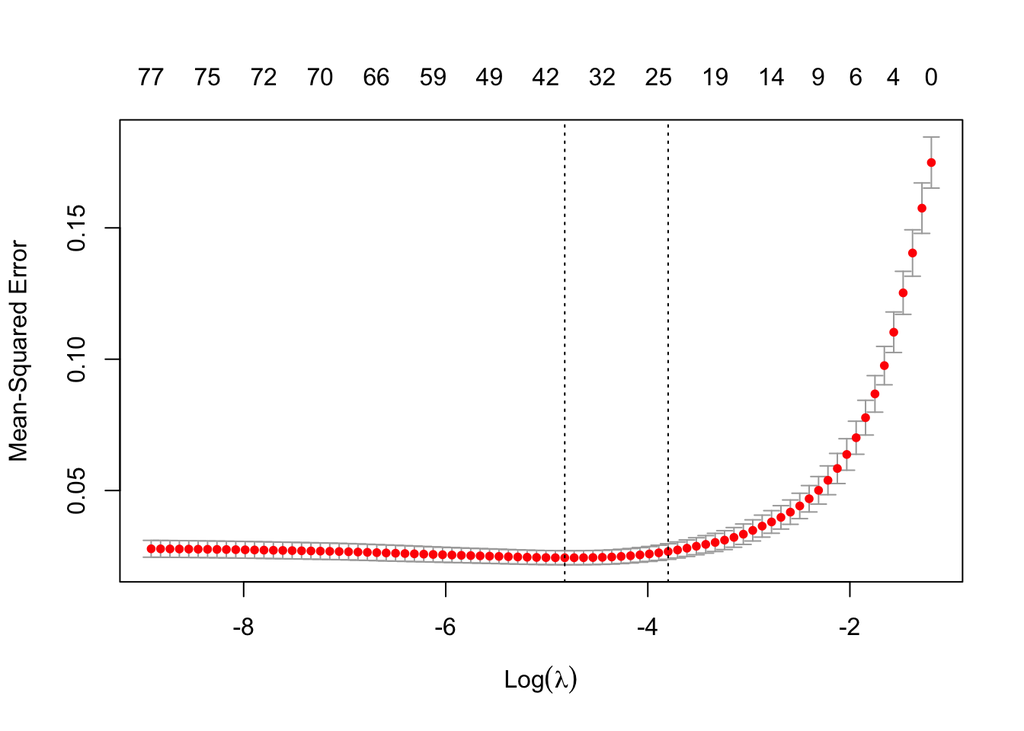

```r
plot(
  x = cv.glmnet_lasso
)
```

For elastic net, we just chose 0.5 here but for a real project we whole bunch of alpha values or a grid search.

```r
cv.glmnet_elasticnet <- glmnet::cv.glmnet(
  x = M[,v_predictors] %>%
    dplyr::filter(M$train_test == "Train") %>%
    as.matrix(),
  y = M$box_cox_sale_price[M$train_test == "Train"],
  alpha = 0.5
)
cv.glmnet_elasticnet
```

```
##
## Call:  glmnet::cv.glmnet(x = M[, v_predictors] %>% dplyr::filter(M$train_test ==      "Train") %>% as.matrix(), y = M$box_cox_sale_price[M$train_test ==      "Train"], alpha = 0.5)
##
## Measure: Mean-Squared Error
##
##     Lambda Index Measure      SE Nonzero
## min 0.0134    42  0.0247 0.00277      40
## 1se 0.0448    29  0.0269 0.00270      29
```

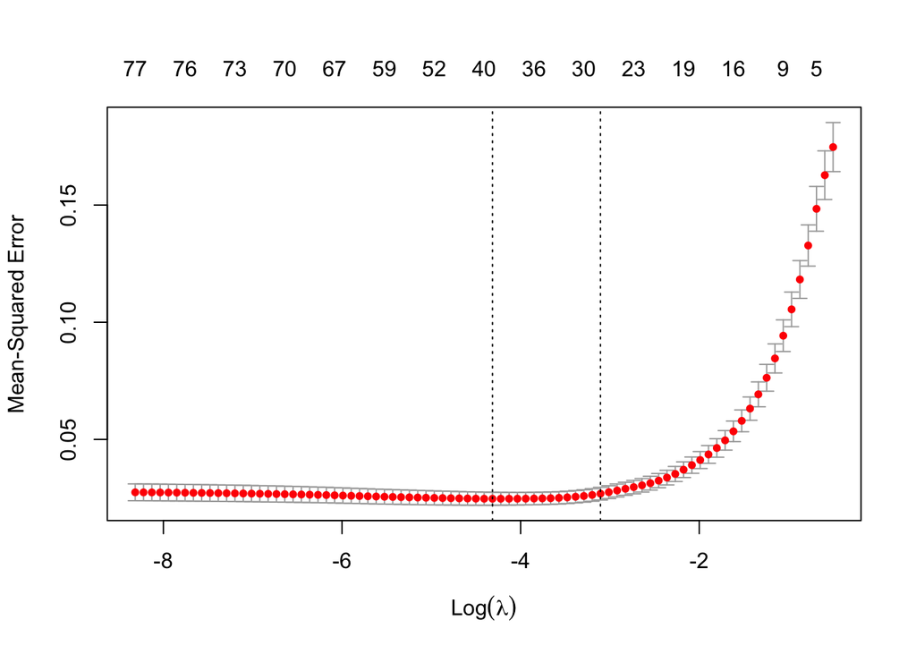

```r
plot(
  x = cv.glmnet_elasticnet
)
```

From the resulting plot, the y-axis shows the mean squared error, and the x-axis shows the log-lambda sequence. The two vertical lines on the plot represent:

1. The lambda value that gives the minimum mean cross-validated error.
2. The largest lambda value such that the error is within one standard error of the minimum.

We like larger lambdas because it shrinks down coefficients more. From the plots, we havent lost a lot of accuracy but we are able shrink out more variables protecting us from multicolinearity and overfitting.

## Selecting the Optimal $\lambda$ (How to extract the value)

- **Lambda that Minimizes the Metric**: This is the value of $\lambda$ that gives the smallest prediction error based on cross-validation. It can be extracted with:

```r
cv.glmnet_lasso$lambda.min
```

```
## [1] 0.0081
```

- **Lambda within 1 Standard Error**: Sometimes, a more regularized model is desired even if the prediction error is slightly higher. This approach provides a simpler model. The $\lambda$ value within one standard error of the minimum can be extracted with:

```r
cv.glmnet_lasso$lambda.1se
```

```
## [1] 0.022
```

The decision on which $\lambda$ to use depends on the goals of the analysis. If predictive accuracy is paramount, then the lambda that minimizes the metric is appropriate. If model interpretability and simplicity are more important, then the lambda within 1 standard error might be more suitable.

# Conclusion Summary

- Ridge regression penalizes the squared magnitude of coefficients, providing a solution to multicollinearity but doesn’t perform feature selection.
- Lasso regression uses an absolute penalty leading to some coefficients being exactly zero, hence facilitating feature selection.
- Elastic-Net is a hybrid of ridge and lasso, balancing between them based on a mixing parameter.

# Homework

1. Find a dataset of your interest with at least 10 predictors. Apply ridge, lasso, and elastic-net regressions and compare the selected features for lasso and elastic-net.
2. Experiment with different values of $\lambda$ (from very small to very large). What do you observe in terms of coefficient shrinkage?
3. Using the same dataset, split it into a training and test set. Evaluate the performance of ridge, lasso, and elastic-net on the test set. Which method performs the best and why?
4. Reflect on the importance of feature selection in real-world applications. Discuss scenarios where you’d prefer lasso over ridge regression and vice-versa.
5. Dive deeper into the `glmnet` documentation. Explore other functionalities the package offers and implement one of your findings on your dataset.

End of lecture notes.